# Report - Problem Set #*2*

Group Members: Giacomo Martiriggiano, Mattia Gallese, Sophie De Becker, Yao Di

This Jupyter Notebook will outline the data cleaning process and binary classification for the churn factor of customers.csv for the assignment

## Data loading

```python
#import modules needed for data analysis
import pandas as pd
import matplotlib.pyplot as plt
import numpy as np
import seaborn as sns
from sklearn.preprocessing import MinMaxScaler, StandardScaler
from sklearn.linear_model import LogisticRegression, LinearRegression
from sklearn.model_selection import train_test_split, KFold, GridSearchCV
from sklearn.metrics import recall_score, accuracy_score, precision_score, confusion_matrix, classification_report
from sklearn.ensemble import RandomForestClassifier
from sklearn import svm
#read the csv file to transfer all the data into "data"
data = pd.read_csv('customers.csv')
```

## Data Cleaning

We keep the data cleaning process as what we did for the Problem Set 1. The first step is to remove the empty value in the TotalCharges column

```python
data['TotalCharges'] = data['TotalCharges'].replace(" ", np.nan).astype('float32')
data["SeniorCitizen"]=data["SeniorCitizen"].astype("object")
data = data[data["TotalCharges"].notnull()]
data = data.reset_index()[data.columns]
#now we forced the 0 and 1 to be objects and we know we can drop the empty values in Total charger
```

Finally a number may be non-empty but still unrealistic for example negative tenure. Let's now check that tenure and charges are non negative

```python
print((data['tenure'] <0).any())
print((data['TotalCharges']<0).any())
print((data['MonthlyCharges']<0).any())
```

```
False
False
False
```

We also need to encode the inputs from enumerates to numbers

### Logistic regression MonthlyCharges

```python
data_origin = data.copy()
y=data_origin.Churn.replace({'No': 0, 'Yes': 1}).values
X_LR = data.iloc[:, 1:20].values

X_train, X_test, y_train, y_test = train_test_split(X_LR, y,stratify=y, test_size=0.2)
X_train_1D = X_train[:, 17, np.newaxis]
X_test_1D = X_test[:, 17, np.newaxis]
classifier = LogisticRegression().fit(X_train_1D, y_train)

accuracy = classifier.score(X_test_1D, y_test)
print('Classification accuracy: {:.2f}%'.format(accuracy * 100))
```

```
Classification accuracy: 73.42%
```

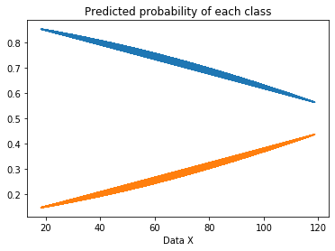

```python
proba = classifier.predict_proba(X_LR[:,17,np.newaxis])
plt.plot(X_LR[:,17], proba)
plt.title('Predicted probability of each class')
plt.xlabel('Data X')
plt.show()
```

### Logistic regression tenure

```python
X_train_1D = X_train[:, 4, np.newaxis]
X_test_1D = X_test[:, 4, np.newaxis]
classifier = LogisticRegression().fit(X_train_1D, y_train)

accuracy = classifier.score(X_test_1D, y_test)
print('Classification accuracy: {:.2f}%'.format(accuracy * 100))
```

```
Classification accuracy: 75.55%
```

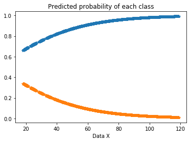

```python
proba = classifier.predict_proba(X_LR[:,17,np.newaxis])
plt.plot(X_LR[:,17], proba, '*')
plt.title('Predicted probability of each class')
plt.xlabel('Data X')
plt.show()
```

### Random Forest

```
(2.0, 0.0)
```

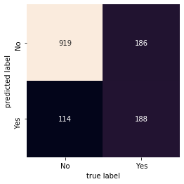

```python
X_RF = data.iloc[:, 1:20]
dfX= pd.get_dummies(X_RF, columns= [i for i in X_RF.columns if X_RF[i].dtypes=='object'],drop_first=True)

y=data['Churn'].values
X_train, X_test, y_train, y_test = train_test_split(dfX, y,stratify=y, test_size=0.2)

classifier= RandomForestClassifier()
classifier.fit(X_train,y_train)
y_pred= classifier.predict(X_test)
mat = confusion_matrix(y_test, y_pred)
s1=sns.heatmap(mat.T, square=True, annot=True, fmt='d', cbar=False,
          xticklabels=['No','Yes'],
          yticklabels=['No','Yes'] )
plt.xlabel('true label')
plt.ylabel('predicted label')
bottom, top = s1.get_ylim()
s1.set_ylim(bottom + 0.5, top - 0.5)
```

## Data numerize and resampling

The key output of our supervised learning model is the "Churn" parameter. The first step is to explore it.

```python
data_E2N = data[['gender', 'SeniorCitizen', 'Partner', 'Dependents',
       'PhoneService', 'MultipleLines', 'InternetService',
       'OnlineSecurity', 'OnlineBackup', 'DeviceProtection', 'TechSupport',
       'StreamingTV', 'StreamingMovies', 'Contract', 'PaperlessBilling',
       'PaymentMethod','Churn']].copy()
data_E2N = data_E2N.apply(lambda x: pd.factorize(x)[0])
scaler = MinMaxScaler()
data_E2N = pd.DataFrame(scaler.fit_transform(data_E2N),columns=data_E2N.columns)
data_N = data[['tenure', 'MonthlyCharges', 'TotalCharges']].copy()
data_N['TotalCharges'] = pd.to_numeric(data_N['TotalCharges'])
scaler2 = StandardScaler()
data_N = pd.DataFrame(scaler2.fit_transform(data_N),columns=data_N.columns)
data_final = pd.concat([data_E2N, data_N], axis=1)
```

```python
data_final.Churn.value_counts()
```

```
0.0    5163
1.0    1869
Name: Churn, dtype: int64
```

As we could observe, the dataset is not balanced based on the churn parameter. In order to get a reliable result, we need to downsampling the No Churn set of customer.

```python
x_train, x_test, y_train, y_test = train_test_split(data_final, data_final["Churn"], stratify=data_final["Churn"],test_size=0.3)
count_nochurn, count_churn = x_train["Churn"].value_counts()

x_train_nochurn = x_train[x_train['Churn'] == 0.0]
x_train_churn = x_train[x_train['Churn'] == 1.0]

x_train_nochurn_resample = x_train_nochurn.sample(count_churn)
x_train_resample = pd.concat([x_train_nochurn_resample, x_train_churn], axis=0)
```

## Problem Solving

For the binary classification problem with multiple dimensions, support vector machine is a common solution to find a robust classifier

```python
classifier = svm.SVC(gamma='auto')
classifier.fit(x_train_resample.drop(columns="Churn"), x_train_resample["Churn"])
y_predict=classifier.predict(x_test.drop(columns="Churn"))
```

```python
print("The accuracy score for the classifier is :",accuracy_score(y_test,y_predict))
print("The recall score for the classifier is :",recall_score(y_test,y_predict,labels=[1,0]))
print("The precision score for the classifier is ::",precision_score(y_test,y_predict,labels=[1,0]))
pd.DataFrame(confusion_matrix(y_test,y_predict,labels=[1,0]), ["Churn_true","No Churn_true"], ["Churn_pred","No Churn_pred"])
```

```
The accuracy score for the classifier is : 0.7530805687203791
The recall score for the classifier is : 0.7754010695187166
The precision score for the classifier is :: 0.5240963855421686
```

|  | Churn_pred | No Churn_pred |
| --- | --- | --- |
| Churn_true | 435 | 126 |
| No Churn_true | 395 | 1154 |

### Cross Validation

We could add cross validation to ensure that our model is not overfitting

```python
Accuracy_scores = []
Recall_scores = []
Precision_scores = []

k = 4
classifier = svm.SVC(gamma='auto')
cv = KFold(n_splits=k, random_state=42, shuffle=False)
for train_index, test_index in cv.split(data_final):
    x_train, x_test, y_train, y_test = data_final.iloc[train_index], data_final.iloc[test_index], data_final.Churn.iloc[train_index], data_final.Churn.iloc[test_index]

    x_train_nochurn = x_train[x_train['Churn'] == 0.0]
    x_train_churn = x_train[x_train['Churn'] == 1.0]

    x_train_nochurn_resample = x_train_nochurn.sample(count_churn)
    x_train_resample = pd.concat([x_train_nochurn_resample, x_train_churn], axis=0)

    classifier.fit(x_train_resample.drop(columns="Churn"), x_train_resample["Churn"])
    y_predict=classifier.predict(x_test.drop(columns="Churn"))
    Accuracy_scores.append(accuracy_score(y_test,y_predict))
    Recall_scores.append(recall_score(y_test,y_predict,labels=[1,0]))
    Precision_scores.append(precision_score(y_test,y_predict,labels=[1,0]))
    print(pd.DataFrame(confusion_matrix(y_test,y_predict,labels=[1,0]), ["Churn_true","No Churn_true"], ["Churn_pred","No Churn_pred"]))

print("The accuracy scores for the ",k, "-fold classifier is :",Accuracy_scores)
print("The recall scores for the ",k, "-fold classifier is :",Recall_scores)
print("The precision scores for the ",k, "-fold classifier is :",Precision_scores)
```

```
               Churn_pred  No Churn_pred
Churn_true            390             70
No Churn_true         412            886
               Churn_pred  No Churn_pred
Churn_true            382             75
No Churn_true         381            920
               Churn_pred  No Churn_pred
Churn_true            369             97
No Churn_true         431            861
               Churn_pred  No Churn_pred
Churn_true            390             96
No Churn_true         371            901
The accuracy scores for the  4 -fold classifier is : [0.7258248009101251, 0.7406143344709898, 0.6996587030716723, 0.7343572241183163]
The recall scores for the  4 -fold classifier is : [0.8478260869565217, 0.8358862144420132, 0.7918454935622318, 0.8024691358024691]
The precision scores for the  4 -fold classifier is : [0.486284289276808, 0.5006553079947575, 0.46125, 0.5124835742444153]
```

### Grid Search

```python
param_grid = [
  {'C': [1, 3, 10, 30, 100], 'kernel': ['linear']},
  {'C': [1, 3, 10, 30, 100], 'kernel': ['rbf'], 'gamma': [0.0001, 0.0003, 0.001]},
 ]
svc = svm.SVC()
classifier=GridSearchCV(svc,param_grid,cv=k)

x_train, x_test, y_train, y_test = train_test_split(data_final, data_final["Churn"], stratify=data_final["Churn"],test_size=0.3)
count_nochurn, count_churn = x_train["Churn"].value_counts()

x_train_nochurn = x_train[x_train['Churn'] == 0.0]
x_train_churn = x_train[x_train['Churn'] == 1.0]

x_train_nochurn_resample = x_train_nochurn.sample(count_churn)
x_train_resample = pd.concat([x_train_nochurn_resample, x_train_churn], axis=0)

classifier.fit(x_train_resample.drop(columns="Churn"), x_train_resample["Churn"])
y_predict=classifier.predict(x_test.drop(columns="Churn"))

print("The accuracy score for the best classifier is :",accuracy_score(y_test,y_predict))
print("The recall score for the best classifier is :",recall_score(y_test,y_predict,labels=[1,0]))
print("The precision score for the best classifier is ::",precision_score(y_test,y_predict,labels=[1,0]))
pd.DataFrame(confusion_matrix(y_test,y_predict,labels=[1,0]), ["Churn_true","No Churn_true"], ["Churn_pred","No Churn_pred"])
```

```
The accuracy score for the best classifier is : 0.7232227488151659
The recall score for the best classifier is : 0.8377896613190731
The precision score for the best classifier is :: 0.48805815160955346
```

|  | Churn_pred | No Churn_pred |
| --- | --- | --- |
| Churn_true | 470 | 91 |
| No Churn_true | 493 | 1056 |